# Bank_Marketing_Analysis

## Data Dictionary

| Column | Variable | Class |
| --- | --- | --- |
| age | age of customer | numeric |
| job | type of job | categorical: "admin.","blue-collar","entrepreneur","housemaid","management","retired","self-employed","services","student","technician","unemployed","unknown" |
| marital | marital status | categorical: "divorced","married","single","unknown"; note: "divorced" means divorced or widowed |
| education | highest degree of customer | categorical: "basic.4y","basic.6y","basic.9y","high.school","illiterate","professional.course","university.degree","unknown" |
| default | has credit in default? | categorical: "no","yes","unknown" |
| housing | has housing loan? | categorical: "no","yes","unknown" |
| loan | has personal loan? | categorical: "no","yes","unknown" |
| contact | contact communication type | categorical: "cellular","telephone" |
| month | last contact month of year | categorical: "jan", "feb", "mar", ..., "nov", "dec" |
| day_of_week | last contact day of the week | categorical: "mon","tue","wed","thu","fri" |
| duration | last contact duration, in seconds | numeric |
| campaign | number of contacts performed during this campaign and for this client | numeric, includes last contact |
| pdays | number of days that passed by after the client was last contacted from a previous campaign | numeric; 999 means client was not previously contacted |
| previous | number of contacts performed before this campaign and for this client | numeric |
| poutcome | outcome of the previous marketing campaign | categorical: "failure","nonexistent","success" |
| emp.var.rate | employment variation rate - quarterly indicator | numeric |
| cons.price.idx | consumer price index - monthly indicator | numeric |
| cons.conf.idx | consumer confidence index - monthly indicator | numeric |
| euribor3m | euribor 3 month rate - daily indicator | numeric |
| nr.employed | number of employees - quarterly indicator | numeric |
| y | has the client subscribed a term deposit? | binary: "yes","no" |

### Motivation:

**Introduction:** The financial services industry is highly competitive, and effective marketing strategies play a pivotal role in achieving success. One of the key objectives for financial institutions is to attract deposits, as they serve as a stable source of funding and contribute to the overall financial health of the organization. Term deposits, in particular, offer a secure investment option for customers while providing banks with a reliable source of funds for lending and investment activities.

**Importance:** Optimizing marketing efforts for term deposit subscriptions is crucial for financial services firms for several reasons. Firstly, successful marketing campaigns can significantly impact the bottom line by increasing revenue through the acquisition of new deposits. Moreover, attracting term deposit customers can enhance customer engagement and loyalty, leading to long-term relationships and potential cross-selling opportunities. Additionally, by effectively targeting the right audience and promoting term deposit products, banks can strengthen their market position and competitive advantage in the industry.

**Goal:** My primary objective is to develop a predictive model that can accurately forecast the likelihood of a customer subscribing to a term deposit. By leveraging machine learning algorithms and analyzing historical campaign data, I aim to identify key factors that influence customers' decision-making processes. Understanding these factors will enable financial institutions to tailor their marketing strategies effectively, thereby maximizing the success of their campaigns and optimizing the allocation of resources.

Through this project, I seek to empower financial services firms with actionable insights to enhance their marketing efforts, drive customer acquisition, and ultimately achieve sustainable growth in the competitive landscape of the industry.

# 1. Import libary

```python
import pandas as pd
import numpy as np
import matplotlib.pyplot as plt
import seaborn as sns
from sklearn.model_selection import train_test_split
from sklearn.preprocessing import LabelEncoder
from sklearn.model_selection import GridSearchCV
from sklearn.model_selection import RandomizedSearchCV
from sklearn.ensemble import RandomForestClassifier
```

## 2. Data Exploration

- Read and understand the structure of the data.
- Check for missing values and handle them if necessary.
- Examine the distribution of numerical variables.
- Calculate descriptive statistics such as mean, variance, min, max of numerical variables.

```python
data = open("D:\\bank-additional-full.csv")
data = pd.read_csv(data)
data.tail()
```

|  | age | job | marital | education | default | housing | loan | contact | month | day_of_week | ... | campaign | pdays | previous | poutcome | emp.var.rate | cons.price.idx | cons.conf.idx | euribor3m | nr.employed | y |
| --- | --- | --- | --- | --- | --- | --- | --- | --- | --- | --- | --- | --- | --- | --- | --- | --- | --- | --- | --- | --- | --- |
| 41183 | 73 | retired | married | professional.course | no | yes | no | cellular | nov | fri | ... | 1 | 999 | 0 | nonexistent | -1.1 | 94.767 | -50.8 | 1.028 | 4963.6 | yes |
| 41184 | 46 | blue-collar | married | professional.course | no | no | no | cellular | nov | fri | ... | 1 | 999 | 0 | nonexistent | -1.1 | 94.767 | -50.8 | 1.028 | 4963.6 | no |
| 41185 | 56 | retired | married | university.degree | no | yes | no | cellular | nov | fri | ... | 2 | 999 | 0 | nonexistent | -1.1 | 94.767 | -50.8 | 1.028 | 4963.6 | no |
| 41186 | 44 | technician | married | professional.course | no | no | no | cellular | nov | fri | ... | 1 | 999 | 0 | nonexistent | -1.1 | 94.767 | -50.8 | 1.028 | 4963.6 | yes |
| 41187 | 74 | retired | married | professional.course | no | yes | no | cellular | nov | fri | ... | 3 | 999 | 1 | failure | -1.1 | 94.767 | -50.8 | 1.028 | 4963.6 | no |

5 rows × 21 columns

```python
data.info()
```

```
<class 'pandas.core.frame.DataFrame'>
RangeIndex: 41188 entries, 0 to 41187
Data columns (total 21 columns):
 #   Column          Non-Null Count  Dtype
---  ------          --------------  -----
 0   age             41188 non-null  int64
 1   job             41188 non-null  object
 2   marital         41188 non-null  object
 3   education       41188 non-null  object
 4   default         41188 non-null  object
 5   housing         41188 non-null  object
 6   loan            41188 non-null  object
 7   contact         41188 non-null  object
 8   month           41188 non-null  object
 9   day_of_week     41188 non-null  object
 10  duration        41188 non-null  int64
 11  campaign        41188 non-null  int64
 12  pdays           41188 non-null  int64
 13  previous        41188 non-null  int64
 14  poutcome        41188 non-null  object
 15  emp.var.rate    41188 non-null  float64
 16  cons.price.idx  41188 non-null  float64
 17  cons.conf.idx   41188 non-null  float64
 18  euribor3m       41188 non-null  float64
 19  nr.employed     41188 non-null  float64
 20  y               41188 non-null  object
dtypes: float64(5), int64(5), object(11)
memory usage: 6.6+ MB
```

```python
data.describe(include='all')
```

|  | age | job | marital | education | default | housing | loan | contact | month | day_of_week | ... | campaign | pdays | previous | poutcome | emp.var.rate | cons.price.idx | cons.conf.idx | euribor3m | nr.employed | y |
| --- | --- | --- | --- | --- | --- | --- | --- | --- | --- | --- | --- | --- | --- | --- | --- | --- | --- | --- | --- | --- | --- |
| count | 41188.00000 | 41188 | 41188 | 41188 | 41188 | 41188 | 41188 | 41188 | 41188 | 41188 | ... | 41188.000000 | 41188.000000 | 41188.000000 | 41188 | 41188.000000 | 41188.000000 | 41188.000000 | 41188.000000 | 41188.000000 | 41188 |
| unique | NaN | 12 | 4 | 8 | 3 | 3 | 3 | 2 | 10 | 5 | ... | NaN | NaN | NaN | 3 | NaN | NaN | NaN | NaN | NaN | 2 |
| top | NaN | admin. | married | university.degree | no | yes | no | cellular | may | thu | ... | NaN | NaN | NaN | nonexistent | NaN | NaN | NaN | NaN | NaN | no |
| freq | NaN | 10422 | 24928 | 12168 | 32588 | 21576 | 33950 | 26144 | 13769 | 8623 | ... | NaN | NaN | NaN | 35563 | NaN | NaN | NaN | NaN | NaN | 36548 |
| mean | 40.02406 | NaN | NaN | NaN | NaN | NaN | NaN | NaN | NaN | NaN | ... | 2.567593 | 962.475454 | 0.172963 | NaN | 0.081886 | 93.575664 | -40.502600 | 3.621291 | 5167.035911 | NaN |
| std | 10.42125 | NaN | NaN | NaN | NaN | NaN | NaN | NaN | NaN | NaN | ... | 2.770014 | 186.910907 | 0.494901 | NaN | 1.570960 | 0.578840 | 4.628198 | 1.734447 | 72.251528 | NaN |
| min | 17.00000 | NaN | NaN | NaN | NaN | NaN | NaN | NaN | NaN | NaN | ... | 1.000000 | 0.000000 | 0.000000 | NaN | -3.400000 | 92.201000 | -50.800000 | 0.634000 | 4963.600000 | NaN |
| 25% | 32.00000 | NaN | NaN | NaN | NaN | NaN | NaN | NaN | NaN | NaN | ... | 1.000000 | 999.000000 | 0.000000 | NaN | -1.800000 | 93.075000 | -42.700000 | 1.344000 | 5099.100000 | NaN |
| 50% | 38.00000 | NaN | NaN | NaN | NaN | NaN | NaN | NaN | NaN | NaN | ... | 2.000000 | 999.000000 | 0.000000 | NaN | 1.100000 | 93.749000 | -41.800000 | 4.857000 | 5191.000000 | NaN |
| 75% | 47.00000 | NaN | NaN | NaN | NaN | NaN | NaN | NaN | NaN | NaN | ... | 3.000000 | 999.000000 | 0.000000 | NaN | 1.400000 | 93.994000 | -36.400000 | 4.961000 | 5228.100000 | NaN |
| max | 98.00000 | NaN | NaN | NaN | NaN | NaN | NaN | NaN | NaN | NaN | ... | 56.000000 | 999.000000 | 7.000000 | NaN | 1.400000 | 94.767000 | -26.900000 | 5.045000 | 5228.100000 | NaN |

11 rows × 21 columns

```python
data.isnull().sum()
```

```
age               0
job               0
marital           0
education         0
default           0
housing           0
loan              0
contact           0
month             0
day_of_week       0
duration          0
campaign          0
pdays             0
previous          0
poutcome          0
emp.var.rate      0
cons.price.idx    0
cons.conf.idx     0
euribor3m         0
nr.employed       0
y                 0
dtype: int64
```

## 3. Data Visualization

```python
# Calculate descriptive statistics for 'age'
age_stats = data['age'].describe()
print("Descriptive statistics for 'age':")
print(age_stats)
```

```
Descriptive statistics for 'age':
count    41188.00000
mean        40.02406
std         10.42125
min         17.00000
25%         32.00000
50%         38.00000
75%         47.00000
max         98.00000
Name: age, dtype: float64
```

Count the number of samples in each group of 'job', 'marital', 'education'

```python
group_counts = data.groupby('job').size()
print("\nNumber of samples in each group of 'job':")
print(group_counts)
```

```
Number of samples in each group of 'job':
job
admin.           10422
blue-collar       9254
entrepreneur      1456
housemaid         1060
management        2924
retired           1720
self-employed     1421
services          3969
student            875
technician        6743
unemployed        1014
unknown            330
dtype: int64
```

```python
group_counts = data.groupby('marital').size()
print("\nNumber of samples in each group of 'marital':")
print(group_counts)
```

```
Number of samples in each group of 'marital':
marital
divorced     4612
married     24928
single      11568
unknown        80
dtype: int64
```

```python
group_counts = data.groupby('education').size()
print("\nNumber of samples in each group of 'education':")
print(group_counts)
```

```
Number of samples in each group of 'education':
education
basic.4y                4176
basic.6y                2292
basic.9y                6045
high.school             9515
illiterate                18
professional.course     5243
university.degree      12168
unknown                 1731
dtype: int64
```

[output not shown]

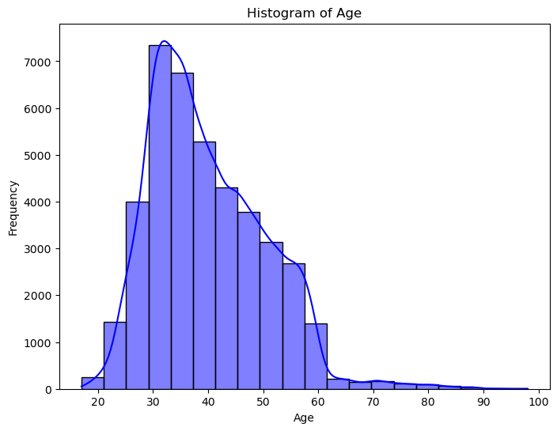

```python
# Histogram of 'age'
plt.figure(figsize=(8, 6))
sns.histplot(data['age'], bins=20, kde=True, color='blue')
plt.title('Histogram of Age')
plt.xlabel('Age')
plt.ylabel('Frequency')
plt.show()
```

[output not shown]

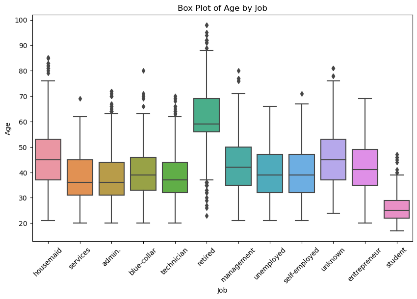

```python
# Bar plot or box plot of 'job' and 'age'
plt.figure(figsize=(10, 6))
sns.boxplot(x='job', y='age', data=data)
plt.title('Box Plot of Age by Job')
plt.xlabel('Job')
plt.ylabel('Age')
plt.xticks(rotation=45)
plt.show()
```

[output not shown]

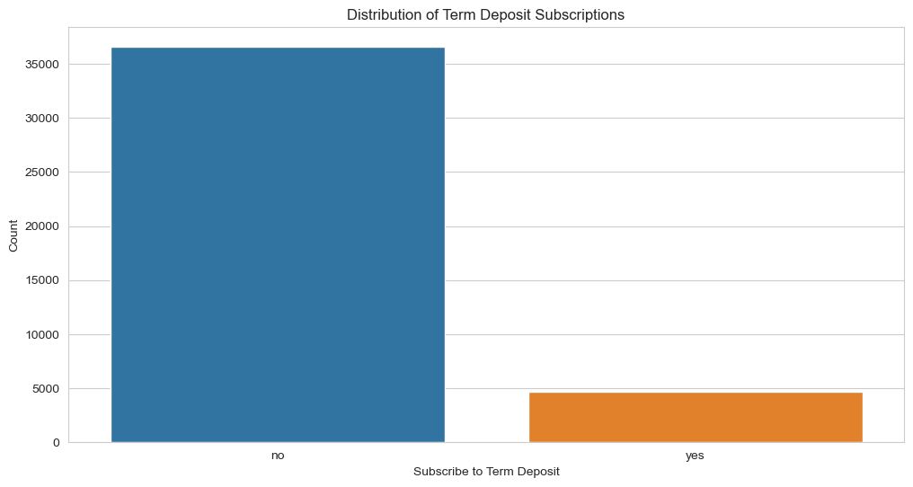

```python
sns.set_style('whitegrid')

# Plot the distribution of the target variable
plt.figure(figsize=(12,6))
sns.countplot(data=data, x='y')
plt.title("Distribution of Term Deposit Subscriptions")
plt.xlabel('Subscribe to Term Deposit')
plt.ylabel('Count')
plt.show()
```

[output not shown]

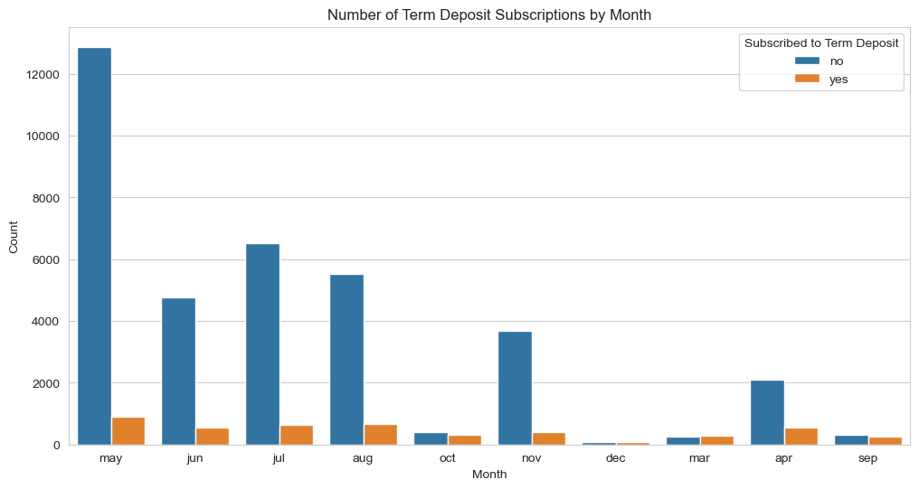

```python
# Plot the number of subscribers by Month
plt.figure(figsize=(12,6))
sns.countplot(data=data, x='month', hue='y')
plt.title('Number of Term Deposit Subscriptions by Month')
plt.xlabel('Month')
plt.ylabel('Count')
plt.legend(title='Subscribed to Term Deposit', loc='upper right')
plt.show()
```

[output not shown]

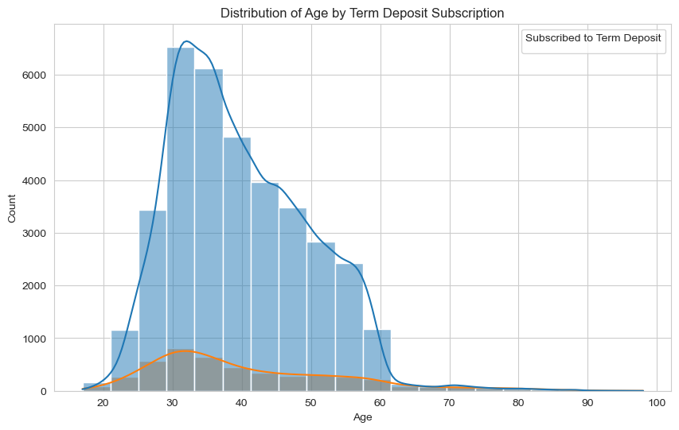

```python
# Plot the distribution of age for subscribers and non-subscribers
plt.figure(figsize=(10, 6))
sns.histplot(data=data, x='age', hue='y', bins=20, kde=True)
plt.title('Distribution of Age by Term Deposit Subscription')
plt.xlabel('Age')
plt.ylabel('Count')
plt.legend(title='Subscribed to Term Deposit', loc='upper right')
plt.show()
```

[output not shown]

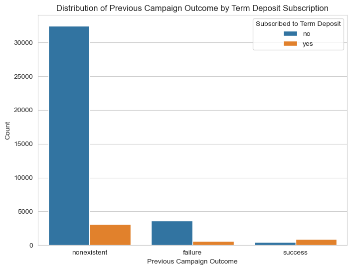

```python
# Plot the distribution of previous campaign outcome for subscribers and non-subscribers
plt.figure(figsize=(8, 6))
sns.countplot(data=data, x='poutcome', hue='y')
plt.title('Distribution of Previous Campaign Outcome by Term Deposit Subscription')
plt.xlabel('Previous Campaign Outcome')
plt.ylabel('Count')
plt.legend(title='Subscribed to Term Deposit', loc='upper right')
plt.show()
```

```python
# Group data by subscription status (yes/no)
subscribed = data[data['y'] == 'yes']
not_subscribed = data[data['y'] == 'no']

# Compare mean age between subscribers and non-subscribers
print("Mean age of subscribers:", subscribed['age'].mean())
print("Mean age of non-subscribers:", not_subscribed['age'].mean())

# Compare distribution of contact types between subscribers and non-subscribers
contact_distribution_subscribed = subscribed['contact'].value_counts(normalize=True)
contact_distribution_not_subscribed = not_subscribed['contact'].value_counts(normalize=True)
print("\nDistribution of contact types among subscribers:")
print(contact_distribution_subscribed)
print("\nDistribution of contact types among non-subscribers:")
print(contact_distribution_not_subscribed)
```

```
Mean age of subscribers: 40.91314655172414
Mean age of non-subscribers: 39.911185290576775

Distribution of contact types among subscribers:
contact
cellular     0.830388
telephone    0.169612
Name: proportion, dtype: float64

Distribution of contact types among non-subscribers:
contact
cellular     0.60991
telephone    0.39009
Name: proportion, dtype: float64
```

```python
from sklearn.ensemble import RandomForestClassifier

# Prepare data for modeling
X = data.drop(columns=['y'])  # Features
y = data['y']  # Target variable

# Encode categorical variables
X_encoded = pd.get_dummies(X)

# Initialize and train Random Forest model
rf_model = RandomForestClassifier(random_state=42)
rf_model.fit(X_encoded, y)

# Get feature importances
feature_importances = rf_model.feature_importances_

# Create a DataFrame to display feature importances
feature_importance_df = pd.DataFrame({'Feature': X_encoded.columns, 'Importance': feature_importances})
feature_importance_df = feature_importance_df.sort_values(by='Importance', ascending=False)

# Display the top features
print("Top features influencing subscription likelihood:")
print(feature_importance_df.head(10))
```

[output not shown]

```
Top features influencing subscription likelihood:
             Feature  Importance
1           duration    0.282914
8          euribor3m    0.097433
0                age    0.081052
9        nr.employed    0.048068
2           campaign    0.040044
3              pdays    0.030514
5       emp.var.rate    0.025021
7      cons.conf.idx    0.023299
6     cons.price.idx    0.022579
62  poutcome_success    0.014163
```

# 3. Data Preprocessing

- Convert categorical variables into numerical form to use machine learning algorithms.
- Normalize the data if necessary.
- Split the data into training and testing sets.

```python
base_data = data.copy()
categorical_cols = ['age','job','marital','education','default','housing','loan','contact','month','day_of_week']
result_col = ['y']
all_cols = categorical_cols + result_col

base_data = base_data[all_cols]

base_data.shape
```

```
(41188, 11)
```

```python
# check unique type
for cols in base_data:
    print(base_data[cols].unique())
```

```
[56 57 37 40 45 59 41 24 25 29 35 54 46 50 39 30 55 49 34 52 58 32 38 44
 42 60 53 47 51 48 33 31 43 36 28 27 26 22 23 20 21 61 19 18 70 66 76 67
 73 88 95 77 68 75 63 80 62 65 72 82 64 71 69 78 85 79 83 81 74 17 87 91
 86 98 94 84 92 89]
['housemaid' 'services' 'admin.' 'blue-collar' 'technician' 'retired'
 'management' 'unemployed' 'self-employed' 'unknown' 'entrepreneur'
 'student']
['married' 'single' 'divorced' 'unknown']
['basic.4y' 'high.school' 'basic.6y' 'basic.9y' 'professional.course'
 'unknown' 'university.degree' 'illiterate']
['no' 'unknown' 'yes']
['no' 'yes' 'unknown']
['no' 'yes' 'unknown']
['telephone' 'cellular']
['may' 'jun' 'jul' 'aug' 'oct' 'nov' 'dec' 'mar' 'apr' 'sep']
['mon' 'tue' 'wed' 'thu' 'fri']
['no' 'yes']
```

```python
# drop "unknown"
base_data = base_data.replace({'marital': {'unknown':np.nan}})
base_data = base_data.replace({'education': {'unknown':np.nan}})
base_data = base_data.replace({'job': {'unknown':np.nan}})
base_data = base_data.replace({'default': {'unknown':np.nan}})
base_data = base_data.replace({'housing': {'unknown':np.nan}})
base_data = base_data.replace({'loan': {'unknown':np.nan}})
base_data = base_data.dropna()
base_data.shape
```

```
(30488, 11)
```

```python
base_data.info()
```

```
<class 'pandas.core.frame.DataFrame'>
Index: 30488 entries, 0 to 41187
Data columns (total 11 columns):
 #   Column       Non-Null Count  Dtype
---  ------       --------------  -----
 0   age          30488 non-null  int64
 1   job          30488 non-null  object
 2   marital      30488 non-null  object
 3   education    30488 non-null  object
 4   default      30488 non-null  object
 5   housing      30488 non-null  object
 6   loan         30488 non-null  object
 7   contact      30488 non-null  object
 8   month        30488 non-null  object
 9   day_of_week  30488 non-null  object
 10  y            30488 non-null  object
dtypes: int64(1), object(10)
memory usage: 2.8+ MB
```

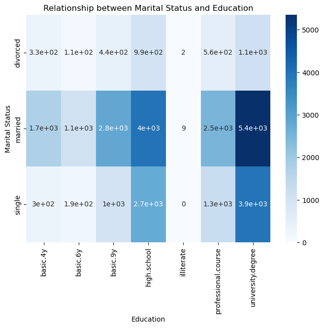

```python
# Heatmap or count plot of 'marital' and 'education'
plt.figure(figsize=(8, 6))
sns.heatmap(pd.crosstab(base_data['marital'], base_data['education']), annot=True, cmap='Blues')
plt.title('Relationship between Marital Status and Education')
plt.xlabel('Education')
plt.ylabel('Marital Status')
plt.show()
```

[output not shown]

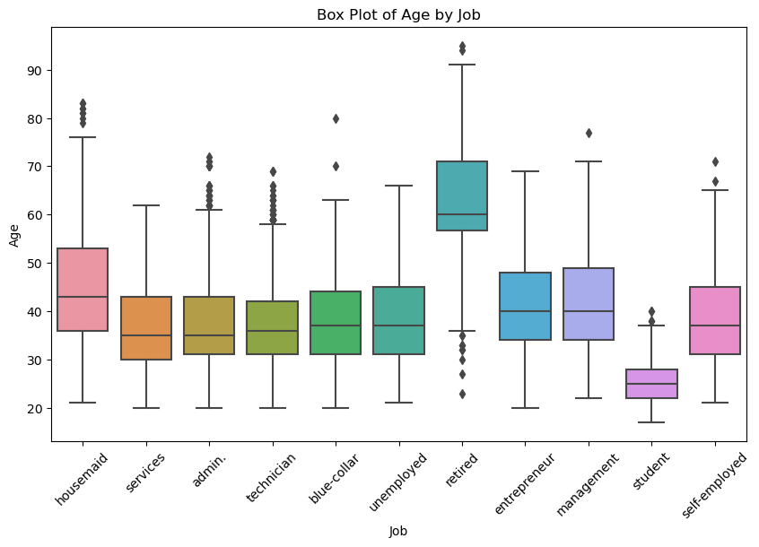

```python
# Bar plot or box plot of 'job' and 'age'
plt.figure(figsize=(10, 6))
sns.boxplot(x='job', y='age', data=base_data)
plt.title('Box Plot of Age by Job')
plt.xlabel('Job')
plt.ylabel('Age')
plt.xticks(rotation=45)
plt.show()
```

[output not shown]

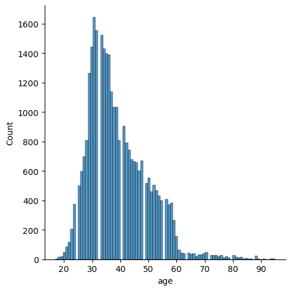

```python
plt.figure(figsize=(12,6))
sns.displot(base_data['age'])
```